# microti data: exploratory analysis

Il dataset microti è costituito da 3868 osservazioni e 10 variabili. E’ un dataset a struttura gerarchica: due livelli nidificati di osservazioni. Il primo livello è costituito dalle informazioni relative al singolo Linfondo: IdLinf (identificativo campione), totalArea ( area totale esaminata del linfonodo), numero di granulomi osservati, esito microbiologico (PCR pos/neg).Complessivamente sono raccolte informazioni da 103 Linfonodi. Il secondo livello, nidificato sotto Linfonodo, è rappresentato dalle informazioni relative ai singoli granulomi esaminati per ogni linfonodo: Area del granuloma, Grado istologico, MNC, NAF e Completezza. Complessivamente sono stati esaminati 3868 granulomi.

### Linfonodi

Il 18% dei linfonodi (19) sono risultati positivi all’esame microbiologico. La distribuzione dell’area del linfonodo è asimmetrica con una coda verso destra che rappresenta pochi linfonodi caraterizzati da un’area totale molto ampia (fig.1)

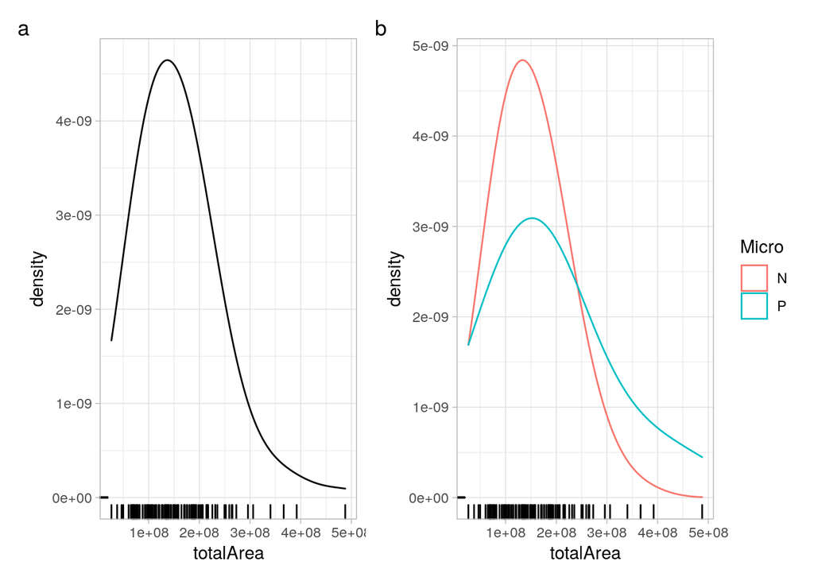

La distribuzione dell’area totale (a)è simile tra i linfonodi Negativi e Positivi all’esame microbiologico; in questi ultimi sembra esserci un maggior numero di linfonodi con area più ampia (parte curva più ampia a destra)(b)

Questo dato può essere utile, soprattutto in riferimento al grafico B, perché fa capire che abbiamo esaminato aree linfonodali confrontabili tra linfonodi microbiologicamente positivi e negativi.

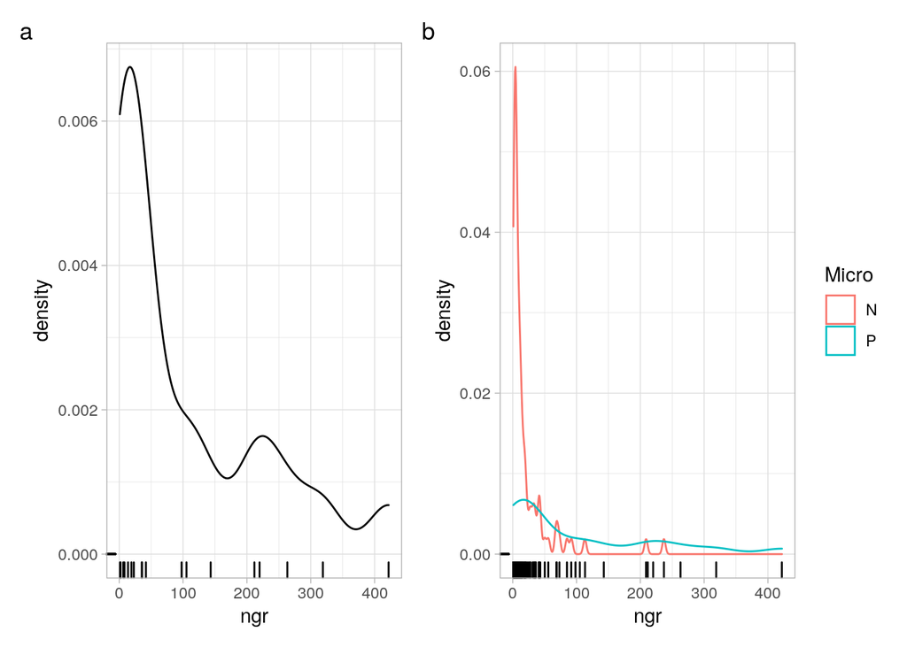

Come leggerai nel commento al grafico successivo vorremmo chiederti se fosse possibile (1) scomporre il grafico B, differenziando i vari gradi (mantenendo la divisione dettata dai risultati dell’esame microbiologico).

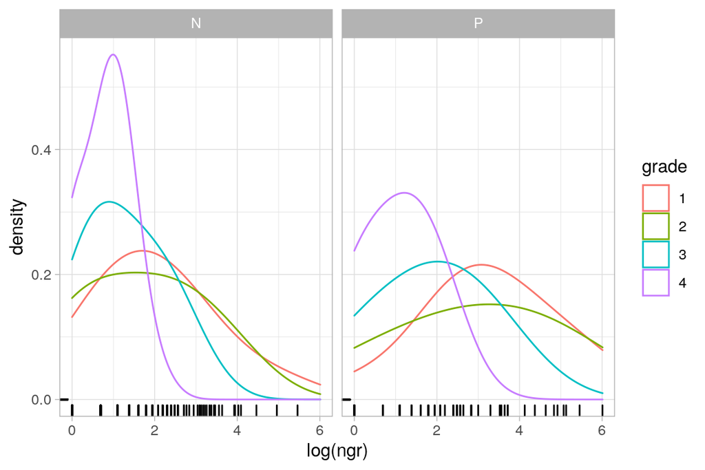

Il grafico si può fare ma non sono sicuro però che abbia senso… perchè lo stesso linfonodo può contribuire con granulomi di diverso grado quindi diventa difficile stabilire se e in che modo il grado istologico (variabili misurata a livello di singolo granuloma -gerarchicamente livello 1) influenza la relazione tra numero di granulomi e status microbiologico (variabili misurate a a livello di singolo linfonodo -gerarchicamente livello 2)

La distribuzione del numero di granulomi per linfonodo condizionalmente allo stato microbiologico è descritta nel seguente grafico.

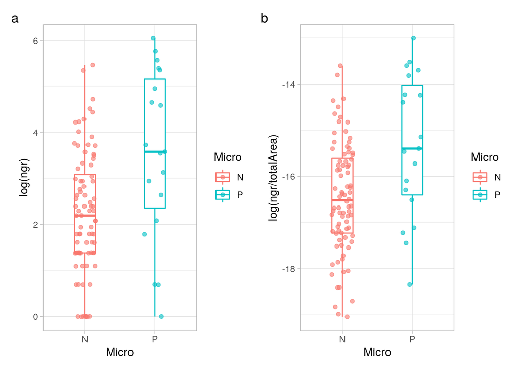

Si può osservare un ampia variabilità in entrambi le classi microbiologiche sia usando i dati osservati che dopo normalizzazione con l’area totale del linfonodo. Il grafico suggerisce che mediamente si osservano più granulomi per linfondo nei casi di positività a microti

Questi grafici sono molto interessanti perché possono avere significato biologico: se l’infezione è “attiva” il micobatterio è metabolicamente attivo e quindi più predisposto a dare microbiologico positivo ed allo stesso tempo possiamo ipotizzare che ci siano più granulomi, dato che l’ospite sta fallendo nel contenere l’infezione. Per questo vorremo provare a (1) scomporre il numero dei granulomi in base al grado, mantenendo la divisone microbiologico negativo vs positivo.

In realtà è già stato fatto con la suddivisione del numero di granulomi per grado e stato microbiologico, ve lo ripropongo, ma riflettendoci su vale quanto scritto prima… il grafico si può fare ma non ha senso o almeno non si può usare il grado istologico per predire lo status microbiologico

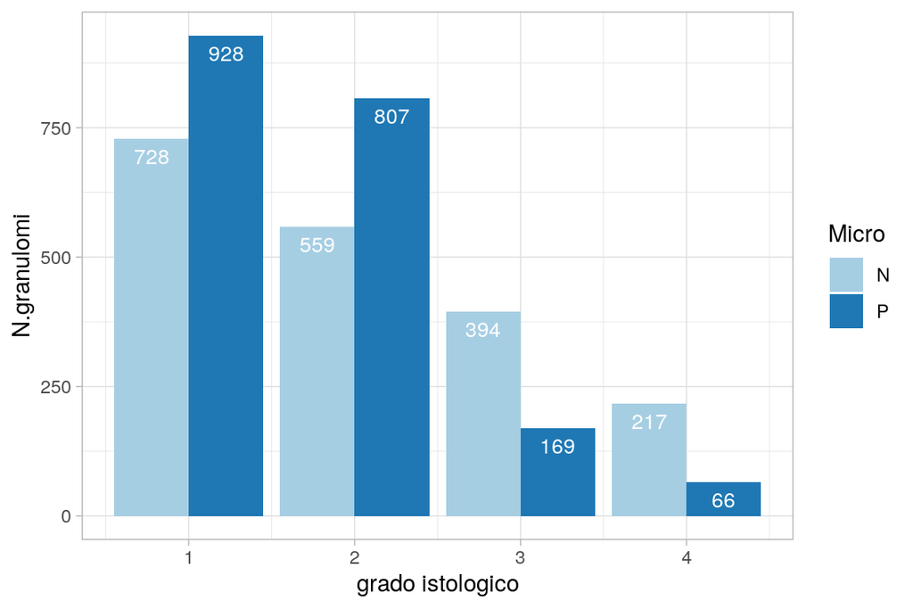

Sempre ricollegandoci a questi grafici volevamo chiederti se fosse possibile costruirne degli altri nei quali, al posto del numero di granulomi per linfonodo, potesse essere considerato come dato (2A) la somma delle aree dei vari gradi

e (2B) dei singoli gradi (normalizzati per l’area linfonodale analizzata) sempre mantenendo la differenza tra microbiologico positivo vs negativo.

In pratica valutare se a parità di area linfonodale considerata, i linfonodi aventi un’area totale di granulomi in generale (1+2+3+4) o un’area totale dei granulomi di grado X superiore ad una certa soglia sono predittivi per positività microbiologica.

In realtà, data la natura gerarchica dei dati, non è possibile predire lo stuatus microbiologico (livello 2), utilizzando come predittori variabili osservate a livello di granulomi ( livello 1), come appunto l’area dei singoli granulomi e il grado istologico.

Come già detto su, non è possibile. La distribuzione del grado istologico varia da linfonodo a linfonodo e quindi anche varibili come dimensione dei granulomi nei diversi gradi istologici, o numero di granulomi dei diversi gradi istologici. Una rappresentazione grafica o tabellare corretta dovrebbe prevedere un grafico /tabella per singolo linfonodo… cioè 103 grafici/tabelle… In questo grafico ho campionato casualmente 20 linfonodi e costruito per ogni linfonodo come si distribuisce il numero di granulomi in base al grado istologico e lo stato microbiologico dei linfonodi. In sostanza la variabilità tra linfonodo, rispetto alle variabili osservate a livello di granuloma è molto elevata quindi non aggregando il dato si perde questa informazione

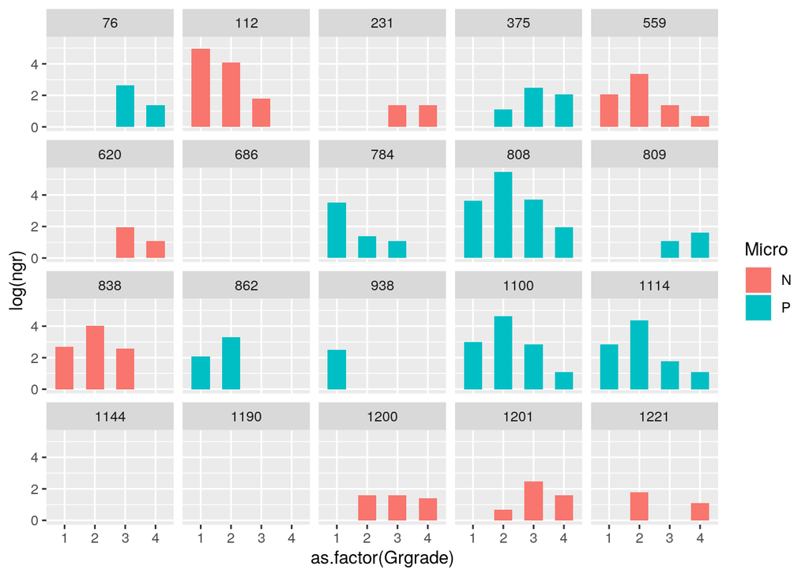

### Granulomi

Volevamo chiederti se (3) fosse possibile eseguire lo stesso calcolo ma differenziando i vari gradi, dicendo per esempio che i granulomi di 4 grado hanno un’area variabile da A a B con dimensione media C. Inoltre, una volta calcolate le dimensioni dei vari gradi, ti chiederemmo se fosse possibile (4) calcolare il diametro medio dei vari gradi, dato che in letteratura viene spesso riportato il diametro e non l’area della lesione.

Anche in questo caso la variabilità della dimensione dei granulomi in base al grading istologico è differente tra i diversi linfonodi. Quindi non è corretto aggreggare la dimensione dei granulomi solo sulla base del grading ignorando il linfonodo di provenienza. Di seguito il grafico di un campione casuale di 20 linfonodi in cui per ogni grado istologico è riportata la distribuzione in quartili (25%-Mediana-75%) della dimensione

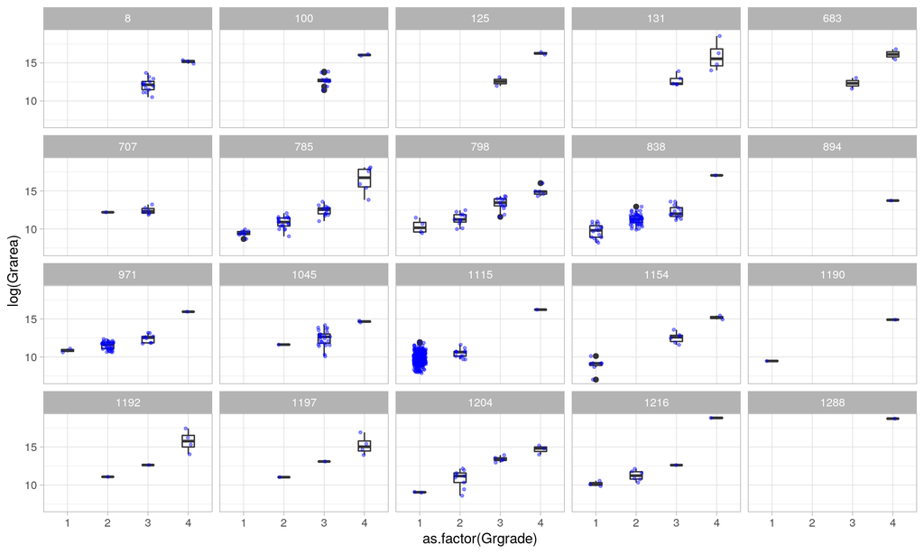

Nel seguente grafico invece è riportata la distribuzione della dimensione dei granulomi di tutti i linfonodi in base al grado istologico.

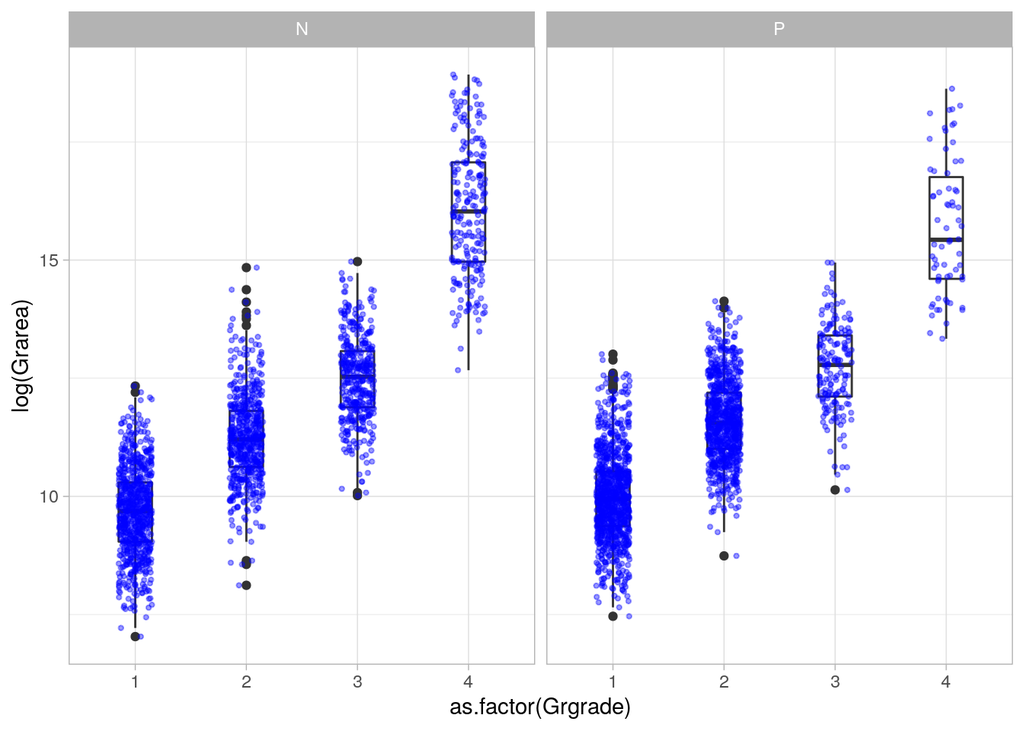

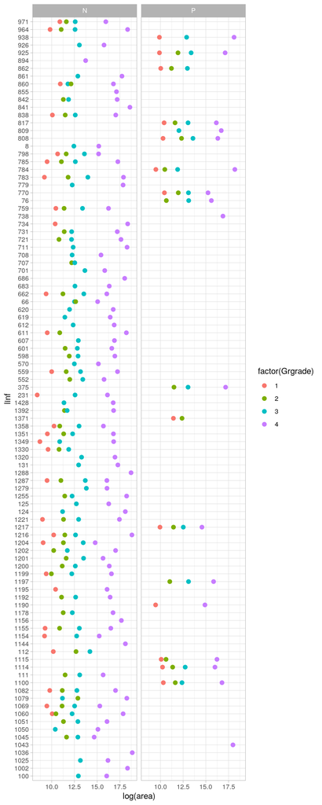

Nel seguente grafico è riportata la distribuzione del numero di granulomi in base alla classificazione per grado istologico (a); si osserva lo stesso pattern sia tra i granulomi di linfonodi microbiologicamente positivi che negativi (b). I granulomi da linf pos sono prevalentemente di grado 1 e 2, mentre il grado 3 e 4 è più frequente tra i i granulomi dei linfonodi negativi.

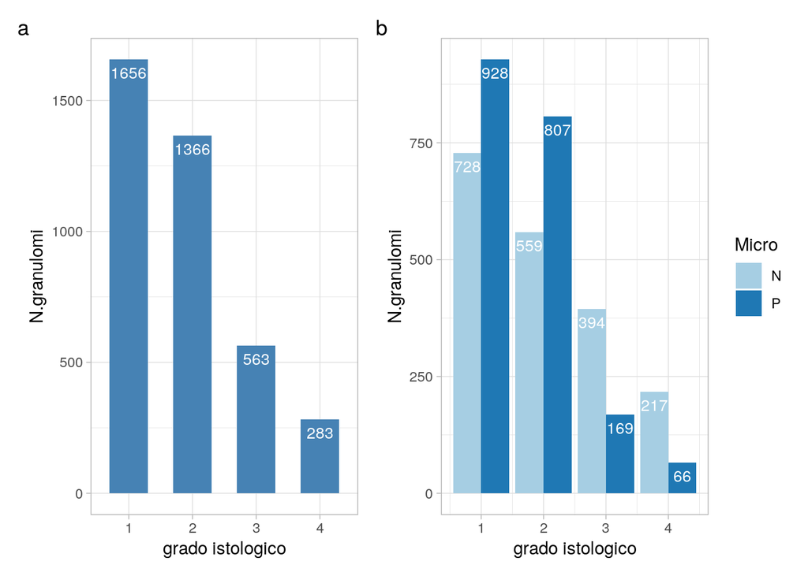

Nel figura seguente è riportato la distibuzione complessiva di MNC (a) che risulta marcatamente asimmetrica (la stragrande maggioranza dei granulomi osservati ha meno di 10 MNC); lo stesso pattern si osserva tra i diversi gradi istologici (b), con differenze da indagare e tra granulomi da linfonodi con differente status microbiologico (c)

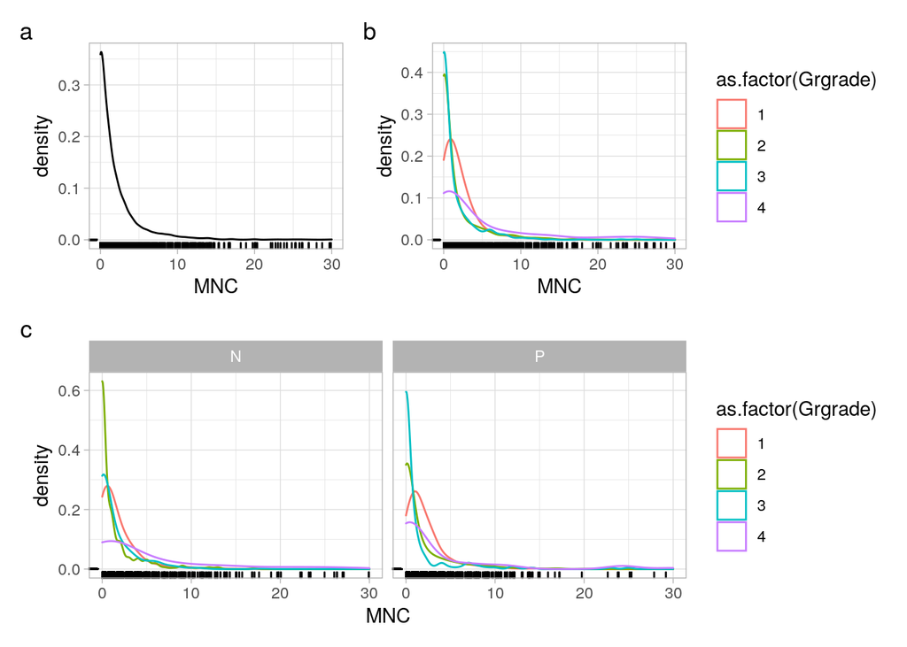

Nel figura seguente è riportato la distibuzione complessiva di NAF (a) che risulta marcatamente asimmetrica: è un riscontro molto raro individuare batteri acido-resistenti; lo stesso pattern si osserva tra i diversi gradi istologici (b), e tra granulomi da linfonodi con differente status microbiologico (c)

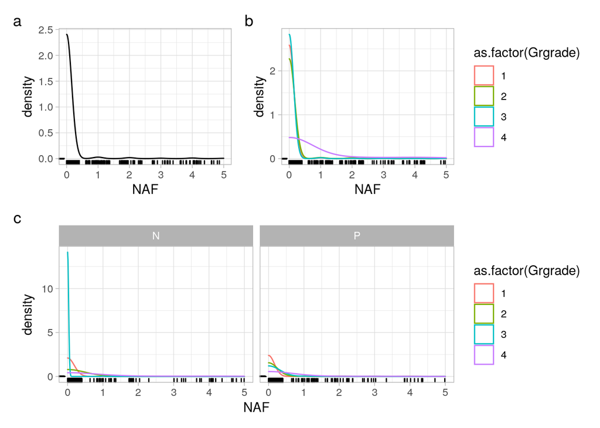